# Exploring cross-species conservation of peak-gene associations in mouse & human ES cells

Erin O’Connor

2025-04-25

#### Initial question - How does doxycycline (dox) exposure influence mammalian embryonic stem cells?

- Background - doxycycline is an antibiotic often used to control transgene expression through Tet-On/Off inducible systems, yet little is known about the impact of dox treatment on embryonic stem cells (mouse or human). The purpose of this investigation is to uncover the genes and pathways influenced with extended dox treatment (various time points up to 150 minutes), and then determine the level of regulation influencing that gene expression (i.e. chromatin regulation vs some other form of gene regulation, potentially post-transcriptional etc).

#### Where is the data for human and mouse?

1. Mouse RNAseq data: /scratch/Shares/rinnclass/MASTER_CLASS/STUDENTS/eroc4824/MASTER_CLASS/lessons/04_RNAseq_Dox/01_Mouse_dox_wt/dox_long/dox_long_out/star_salmon/
2. Mouse ATAC data: /scratch/Shares/rinnclass/MASTER_CLASS/lessons/08_ATACseq_pipeline/00_run_pipeline/00_pipeline_run/pipeline_run/bwa/merged_library/macs2/broad_peak
3. Human RNAseq data: /scratch/Shares/rinnclass/MASTER_CLASS/DATA/human_rnaseq
4. Human ATAC data: /scratch/Shares/rinnclass/MASTER_CLASS/DATA/human_atacseq

#### Versions:

- R version - R 4.3.1
- Install Java 21 prior to running Nextflow - module load openjdk/21.0.1
- nf-core/rnaseq version 3.14.0
- Genomes - mouse GRCm38.p6.genome.fa, human GRCh38 (hg38)

#### Set up files for DESeq2

Create sample metadata (colData) assigning sample info:  
Tells DESeq2 which timepoint, time group, & replicate is associated with each sample

```r
# laod Salmon counts from NF_CORE run 3.14
counts_matrix_mouse <- read.table("/scratch/Shares/rinnclass/MASTER_CLASS/STUDENTS/eroc4824/MASTER_CLASS/lessons/04_RNAseq_Dox/01_Mouse_dox_wt/dox_long/dox_long_out/star_salmon/salmon.merged.gene_counts.tsv", header=TRUE, row.names=1)

# prepare counts for DESEQ
# create g2s with gene_id and gene_name info
g2s_mouse <- data.frame(
  gene_id = rownames(counts_matrix_mouse),
  gene_name = counts_matrix_mouse[, 1]
)

# remove gene name column
counts_matrix_mouse <-counts_matrix_mouse %>%
  select(-"gene_name")
counts_integer <- round(counts_matrix_mouse)
counts_filtered  <- counts_matrix_mouse[rowSums(counts_matrix_mouse) > 1, ]

# Create a dataframe from counts_matrix that includes all column names:
deseq_samples_mouse <- data.frame(
  sample_id = colnames(counts_matrix_mouse))

split_values <- strsplit(deseq_samples_mouse$sample_id, "_")
time_values <- sapply(split_values, function(x) x[[2]]) # extract the 2nd value
replicate_values <- sapply(split_values, function(x) x[[3]]) # extract the 3rd value
deseq_samples_mouse$time_point <- time_values # add a column with time_values
deseq_samples_mouse$replicate <- replicate_values  # add a column for replicates

deseq_samples_mouse$time_point <- factor(deseq_samples_mouse$time_point)
deseq_samples_mouse$replicate <- factor(deseq_samples_mouse$replicate)

kable(head(deseq_samples_mouse), caption = "Mouse DESeq Sample Sheet")
```

Mouse DESeq Sample Sheet

| sample_id | time_point | replicate |
| --- | --- | --- |
| WT_0_1 | 0 | 1 |
| WT_0_2 | 0 | 2 |
| WT_0_3 | 0 | 3 |
| WT_12_1 | 12 | 1 |
| WT_12_2 | 12 | 2 |
| WT_12_3 | 12 | 3 |

#### Run DESeq2 for the mouse dox samples, comparing all time points to 0h:

```r
# test that the sample sheet and counts are arranged properly
stopifnot(all(colnames(counts_integer) == deseq_samples_mouse$sample_id))

# set up the dds
dds_time_point_mouse <- DESeqDataSetFromMatrix(countData = counts_integer,
                              colData = deseq_samples_mouse,
                              design = ~ time_point)
# run deseq
dds_time_point_mouse <- DESeq(dds_time_point_mouse)
```

#### Extract the mouse DESeq2 results for each time point

```r
# set up result names object for input to for-loop
result_names <- resultsNames(dds_time_point_mouse)
results_names <- result_names[-1]

# Set up the dataframe - this will be filled in with the output of the for-loop
res_df <- data.frame("gene_id" = character(),
                     "baseMean" = numeric(),
                     "log2FoldChange" = numeric(),
                     "lfcSE" = numeric(),
                     "stat" = numeric(),
                     "pvalue" = numeric(),
                     "padj" = numeric(),
                     "gene_name" = character(),
                     "result_name" = character())

# run for loop to retreive results from all time comparisons in dds
for(i in 1:length(results_names)) {
  results_name <- results_names[i]
  res <- results(dds_time_point_mouse, name = results_name)
  # temporary results data frame:
  tmp_res_df <- res %>%
    as.data.frame() %>%
    rownames_to_column("gene_id") %>%
    merge(g2s_mouse) %>%
    mutate(result_name = results_name)
  # the below code tells each iteration of the loop to put the output into the res_df data frame, then run the next iteration
  res_df <- bind_rows(res_df, tmp_res_df)
}
```

#### Filter for significant results based on padj<0.05 and L2FC>[1]

```r
filtered_res_df_mouse <- res_df %>%
  filter(padj < 0.05, abs(log2FoldChange) > 1)

unique_sig_genes <- unique(filtered_res_df_mouse$gene_id)
cat("Number of unique mouse genes that change with dox:", length(unique_sig_genes), "\n")
```

```
## Number of unique mouse genes that change with dox: 666
```

#### There are 666 individual genes that change significantly with dox across all time points.

#### Export the DESeq2 results for these unique sig genes:

```r
# extract the data from filtered_res_df_mouse for these unique_sig_genes:
sig_gene_results_mouse <- filtered_res_df_mouse %>%
  filter(gene_id %in% unique_sig_genes)

# move gene_name to the first column
sig_gene_results_mouse <- sig_gene_results_mouse %>%
  select(gene_name, everything())

# now write that into a table, save in your results folder:
write.csv(sig_gene_results_mouse, file = "/scratch/Shares/rinnclass/MASTER_CLASS/STUDENTS/eroc4824/MASTER_CLASS/lessons/08_ATACseq_pipeline/eroc4824_FINAL_PROJECT/results/DESeq2_sig_gene_results_mouse.csv", row.names = FALSE)

# Show top 6 rows of unique significant DESeq2 results (already saved)
knitr::kable(head(sig_gene_results_mouse), caption = "Example of unique significant mouse genes that change in response to dox (padj < 0.05, L2FC > [1])")
```

Example of unique significant mouse genes that change in response to dox (padj < 0.05, L2FC > [1])

| gene_name | gene_id | baseMean | log2FoldChange | lfcSE | stat | pvalue | padj | result_name |
| --- | --- | --- | --- | --- | --- | --- | --- | --- |
| Gm5620 | ENSMUSG00000056904.3 | 60.80897 | -1.484904 | 0.2556081 | -5.809300 | 0.00e+00 | 0.0000028 | time_point_12_vs_0 |
| Gm17383 | ENSMUSG00000058625.6 | 29.01787 | 1.652564 | 0.3964894 | 4.167991 | 3.07e-05 | 0.0020404 | time_point_12_vs_0 |
| Rps3a3 | ENSMUSG00000059751.7 | 132.14652 | 1.075783 | 0.1849471 | 5.816707 | 0.00e+00 | 0.0000028 | time_point_12_vs_0 |
| Gm11353 | ENSMUSG00000060198.7 | 166.06513 | 1.102955 | 0.1807453 | 6.102260 | 0.00e+00 | 0.0000006 | time_point_12_vs_0 |
| mt-Atp6 | ENSMUSG00000064357.1 | 52301.22972 | 1.143431 | 0.0811614 | 14.088355 | 0.00e+00 | 0.0000000 | time_point_12_vs_0 |
| Gm10157 | ENSMUSG00000066270.3 | 21.71892 | 1.690537 | 0.4090852 | 4.132482 | 3.59e-05 | 0.0022777 | time_point_12_vs_0 |

#### Filter for mouse genes UPregulated with dox

The following tables depict the top significantly upregulated genes across all dox exposure time points.

```r
up_genes_mouse <- sig_gene_results_mouse %>%
  filter(log2FoldChange > 1)

# print the number of upregulated genes
cat("Number of upregulated genes:", nrow(up_genes_mouse), "\n")
```

```
## Number of upregulated genes: 557
```

```r
write.csv(up_genes_mouse,
          file = "/scratch/Shares/rinnclass/MASTER_CLASS/STUDENTS/eroc4824/MASTER_CLASS/lessons/08_ATACseq_pipeline/eroc4824_FINAL_PROJECT/results/upregulated_dox_genes_mouse.csv",
          row.names = FALSE)

kable(
  head(up_genes_mouse %>% arrange(desc(log2FoldChange))),
  caption = "Top 6 Upregulated Genes (log2FC > 1)"
)
```

Top 6 Upregulated Genes (log2FC > 1)

| gene_name | gene_id | baseMean | log2FoldChange | lfcSE | stat | pvalue | padj | result_name |
| --- | --- | --- | --- | --- | --- | --- | --- | --- |
| Gm13694 | ENSMUSG00000096337.1 | 51.24488 | 21.82956 | 4.712097 | 4.632664 | 0.0000036 | 0.0000541 | time_point_96_vs_0 |
| Gm13694 | ENSMUSG00000096337.1 | 51.24488 | 20.77000 | 4.712806 | 4.407142 | 0.0000105 | 0.0000851 | time_point_48_vs_0 |
| Gm13694 | ENSMUSG00000096337.1 | 51.24488 | 20.22750 | 4.713164 | 4.291704 | 0.0000177 | 0.0013158 | time_point_12_vs_0 |
| Pgk1-rs7 | ENSMUSG00000066632.3 | 174.89202 | 11.01546 | 3.002998 | 3.668155 | 0.0002443 | 0.0014410 | time_point_48_vs_0 |
| Pgk1-rs7 | ENSMUSG00000066632.3 | 174.89202 | 10.98764 | 3.002961 | 3.658936 | 0.0002533 | 0.0102089 | time_point_12_vs_0 |
| Pgk1-rs7 | ENSMUSG00000066632.3 | 174.89202 | 10.61912 | 3.003144 | 3.536001 | 0.0004062 | 0.0025544 | time_point_24_vs_0 |

#### Filter for mouse genes DOWNregulated with dox

The following tables depict the top significantly downregulated genes across all dox exposure time points.

```r
down_genes_mouse <- sig_gene_results_mouse %>%
  filter(log2FoldChange < -1)

# print the number of downregulated genes
cat("Number of downregulated genes:", nrow(down_genes_mouse), "\n")
```

```
## Number of downregulated genes: 359
```

```r
write.csv(down_genes_mouse,
          file = "/scratch/Shares/rinnclass/MASTER_CLASS/STUDENTS/eroc4824/MASTER_CLASS/lessons/08_ATACseq_pipeline/eroc4824_FINAL_PROJECT/results/downregulated_genes_mouse.csv",
          row.names = FALSE)

kable(
  head(down_genes_mouse %>% arrange(log2FoldChange)),
  caption = "Top 6 Downregulated Genes (log2FC < -1)"
)
```

Top 6 Downregulated Genes (log2FC < -1)

| gene_name | gene_id | baseMean | log2FoldChange | lfcSE | stat | pvalue | padj | result_name |
| --- | --- | --- | --- | --- | --- | --- | --- | --- |
| Gm13698 | ENSMUSG00000094125.1 | 146.14440 | -23.31381 | 4.065463 | -5.734601 | 0.0e+00 | 3.70e-06 | time_point_12_vs_0 |
| Gm13693 | ENSMUSG00000094336.1 | 42.84881 | -23.23765 | 4.712140 | -4.931443 | 8.0e-07 | 8.30e-06 | time_point_48_vs_0 |
| Gm45234 | ENSMUSG00000107478.1 | 91.68357 | -22.96298 | 2.767198 | -8.298279 | 0.0e+00 | 0.00e+00 | time_point_12_vs_0 |
| Gm48419 | ENSMUSG00000112984.1 | 50.61457 | -22.38298 | 3.818425 | -5.861836 | 0.0e+00 | 1.00e-07 | time_point_24_vs_0 |
| Gm49388 | ENSMUSG00000108815.1 | 25.66519 | -22.10880 | 4.713144 | -4.690881 | 2.7e-06 | 4.19e-05 | time_point_96_vs_0 |
| Gm9049 | ENSMUSG00000112919.1 | 30.31830 | -21.75887 | 4.564816 | -4.766649 | 1.9e-06 | 2.25e-05 | time_point_24_vs_0 |

```r
save(deseq_samples_mouse, counts_matrix_mouse, sig_gene_results_mouse, up_genes_mouse, down_genes_mouse,
     file = "/scratch/Shares/rinnclass/MASTER_CLASS/STUDENTS/eroc4824/MASTER_CLASS/lessons/08_ATACseq_pipeline/eroc4824_FINAL_PROJECT/results/mouse_DESeq_data.RData")
```

Okay, now let’s use this same approach to look at dox response in human ES cells (starting with the RNA-seq).

### HUMAN:

#### Load human counts files:

```r
# Load Salmon gene-level counts
counts_matrix_human <- read.table("/scratch/Shares/rinnclass/MASTER_CLASS/DATA/human_rnaseq/salmon.merged.gene_counts.tsv", header = TRUE, row.names = 1)

# Create g2s: gene_id + gene_name
g2s_human <- data.frame(
  gene_id = rownames(counts_matrix_human),
  gene_name = counts_matrix_human[, 1]
)

# Remove gene_name for DESeq2
counts_matrix_human <- counts_matrix_human %>% select(-"gene_name")
counts_integer_human <- round(counts_matrix_human)

# Sample metadata
deseq_samples_human <- data.frame(sample_id = colnames(counts_matrix_human))
split_vals <- strsplit(deseq_samples_human$sample_id, "_")
deseq_samples_human$time_point <- sapply(split_vals, function(x) x[[2]])
deseq_samples_human$replicate <- sapply(split_vals, function(x) x[[3]])
deseq_samples_human$time_point <- factor(deseq_samples_human$time_point)
deseq_samples_human$replicate <- factor(deseq_samples_human$replicate)

# Save colData
save(deseq_samples_human, counts_matrix_human,
     file = "/scratch/Shares/rinnclass/MASTER_CLASS/STUDENTS/eroc4824/MASTER_CLASS/lessons/08_ATACseq_pipeline/eroc4824_FINAL_PROJECT/results/human_DESeq_data.RData")
```

#### run DESeq2

```r
# Check sample alignment
stopifnot(all(colnames(counts_integer_human) == deseq_samples_human$sample_id))

# DESeq2 object
dds_human <- DESeqDataSetFromMatrix(countData = counts_integer_human,
                                    colData = deseq_samples_human,
                                    design = ~ time_point)
# Run DESeq
dds_human <- DESeq(dds_human)
```

#### Extract the DESeq2 results for the human time point v 0h

```r
results_names_human <- resultsNames(dds_human)[-1]  # remove intercept
res_df_human <- data.frame()

for (res_name in results_names_human) {
  res <- results(dds_human, name = res_name)
  tmp <- as.data.frame(res) %>%
    rownames_to_column("gene_id") %>%
    merge(g2s_human, by = "gene_id") %>%
    mutate(result_name = res_name)
  res_df_human <- bind_rows(res_df_human, tmp)
}
```

#### Filter significant results (padj < 0.05, L2FC > [1])

```r
filtered_res_df_human <- res_df_human %>%
  filter(padj < 0.05, abs(log2FoldChange) > 1)

unique_sig_genes_human <- unique(filtered_res_df_human$gene_id)
cat("Number of unique human genes that change with dox:", length(unique_sig_genes_human), "\n")
```

```
## Number of unique human genes that change with dox: 7338
```

```r
# Extract full table of those genes
sig_gene_results_human <- filtered_res_df_human %>%
  filter(gene_id %in% unique_sig_genes_human) %>%
  select(gene_name, everything())

write.csv(sig_gene_results_human,
          file = "/scratch/Shares/rinnclass/MASTER_CLASS/STUDENTS/eroc4824/MASTER_CLASS/lessons/08_ATACseq_pipeline/eroc4824_FINAL_PROJECT/results/DESeq2_sig_gene_results_human.csv",
          row.names = FALSE)

# Preview table
knitr::kable(head(sig_gene_results_human), caption = "Top significant human genes that change in response to dox")
```

Top significant human genes that change in response to dox

| gene_name | gene_id | baseMean | log2FoldChange | lfcSE | stat | pvalue | padj | result_name |
| --- | --- | --- | --- | --- | --- | --- | --- | --- |
| AOC1 | ENSG00000002726.21 | 13.68415 | -1.704928 | 0.6772389 | -2.517469 | 0.0118201 | 0.0469239 | time_point_0.5_vs_0 |
| CYP26B1 | ENSG00000003137.9 | 22.35011 | -2.900878 | 0.7841270 | -3.699500 | 0.0002160 | 0.0049985 | time_point_0.5_vs_0 |
| ABCC8 | ENSG00000006071.16 | 116.10073 | -1.442360 | 0.3769006 | -3.826898 | 0.0001298 | 0.0037828 | time_point_0.5_vs_0 |
| ALDH3B1 | ENSG00000006534.16 | 51.73350 | -2.074138 | 0.5637781 | -3.678998 | 0.0002342 | 0.0052318 | time_point_0.5_vs_0 |
| USH1C | ENSG00000006611.17 | 83.51198 | -1.224415 | 0.3869290 | -3.164443 | 0.0015538 | 0.0149653 | time_point_0.5_vs_0 |
| FMO3 | ENSG00000007933.13 | 5.00486 | -5.177744 | 1.7031880 | -3.040031 | 0.0023655 | 0.0186170 | time_point_0.5_vs_0 |

#### There are 7,338 individual human genes that change significantly with dox across all time points.

#### Upregulated human genes

```r
up_genes_human <- sig_gene_results_human %>% filter(log2FoldChange > 1)

cat("Number of upregulated genes (human):", nrow(up_genes_human), "\n")
```

```
## Number of upregulated genes (human): 4256
```

```r
write.csv(up_genes_human,
          "/scratch/Shares/rinnclass/MASTER_CLASS/STUDENTS/eroc4824/MASTER_CLASS/lessons/08_ATACseq_pipeline/eroc4824_FINAL_PROJECT/results/upregulated_dox_genes_human.csv",
          row.names = FALSE)

kable(
  head(up_genes_human %>% arrange(desc(log2FoldChange))),
  caption = "Top 6 Upregulated Human Genes (log2FC > 1)"
)
```

Top 6 Upregulated Human Genes (log2FC > 1)

| gene_name | gene_id | baseMean | log2FoldChange | lfcSE | stat | pvalue | padj | result_name |
| --- | --- | --- | --- | --- | --- | --- | --- | --- |
| U2 | ENSG00000278774.1 | 19.347413 | 26.15391 | 7.5921713 | 3.444852 | 0.0005714 | 0.0075049 | time_point_3.5_vs_0 |
| SCARNA17 | ENSG00000251992.1 | 2.937267 | 21.91503 | 6.6433653 | 3.298784 | 0.0009710 | 0.0056420 | time_point_12_vs_0 |
| CELA3B | ENSG00000219073.8 | 143.678402 | 11.17920 | 1.0069608 | 11.101917 | 0.0000000 | 0.0000000 | time_point_24_vs_0 |
| CELA3B | ENSG00000219073.8 | 143.678402 | 11.09613 | 1.0070995 | 11.017912 | 0.0000000 | 0.0000000 | time_point_96_vs_0 |
| CELA3B | ENSG00000219073.8 | 143.678402 | 11.09162 | 1.0072244 | 11.012062 | 0.0000000 | 0.0000000 | time_point_48_vs_0 |
| TMEM30BP1 | ENSG00000250995.1 | 390.688103 | 10.77918 | 0.7476091 | 14.418205 | 0.0000000 | 0.0000000 | time_point_24_vs_0 |

#### Downregulated human genes

```r
down_genes_human <- sig_gene_results_human %>% filter(log2FoldChange < -1)

cat("Number of downregulated genes (human):", nrow(down_genes_human), "\n")
```

```
## Number of downregulated genes (human): 21117
```

```r
write.csv(down_genes_human,
          "/scratch/Shares/rinnclass/MASTER_CLASS/STUDENTS/eroc4824/MASTER_CLASS/lessons/08_ATACseq_pipeline/eroc4824_FINAL_PROJECT/results/downregulated_genes_human.csv",
          row.names = FALSE)

kable(
  head(down_genes_human %>% arrange(log2FoldChange)),
  caption = "Top 6 Downregulated Human Genes (log2FC < -1)"
)
```

Top 6 Downregulated Human Genes (log2FC < -1)

| gene_name | gene_id | baseMean | log2FoldChange | lfcSE | stat | pvalue | padj | result_name |
| --- | --- | --- | --- | --- | --- | --- | --- | --- |
| U2 | ENSG00000273709.1 | 62.82625 | -28.47348 | 4.543862 | -6.266361 | 0e+00 | 0.00e+00 | time_point_24_vs_0 |
| U2 | ENSG00000274432.1 | 93.00291 | -25.07562 | 4.078406 | -6.148388 | 0e+00 | 0.00e+00 | time_point_24_vs_0 |
| CENPVL2 | ENSG00000283093.1 | 92.26022 | -24.75830 | 3.439920 | -7.197347 | 0e+00 | 0.00e+00 | time_point_12_vs_0 |
| RP1-37E16.12 | ENSG00000100101.15 | 56.22791 | -23.82413 | 3.692784 | -6.451535 | 0e+00 | 0.00e+00 | time_point_4.5_vs_0 |
| RP1-37E16.12 | ENSG00000100101.15 | 56.22791 | -23.61221 | 3.692784 | -6.394148 | 0e+00 | 1.00e-07 | time_point_3_vs_0 |
| U2 | ENSG00000274432.1 | 93.00291 | -23.42553 | 4.700086 | -4.984065 | 6e-07 | 5.03e-05 | time_point_4.5_vs_0 |

```r
save(deseq_samples_human, counts_matrix_human, sig_gene_results_human, up_genes_human, down_genes_human,
     file = "/scratch/Shares/rinnclass/MASTER_CLASS/STUDENTS/eroc4824/MASTER_CLASS/lessons/08_ATACseq_pipeline/eroc4824_FINAL_PROJECT/results/mouse_DESeq_data.RData")
```

#### Result - there seem to be more genes in human ES cells that are affected by dox exposure.

#### Next, I want to ask how much overlap there is between mouse and human up and down dox genes:

#### Load ortholog information for human/mouse to connect the genes in each list:

```r
library(BiocManager)

library(biomaRt)
library(Biostrings)
library(XML)
library(RCurl)
library(httr)
library(jsonlite)
library(data.table)
library(BiocGenerics)
library(Biobase)
library(S4Vectors)
library(IRanges)
library(AnnotationDbi)
library(GenomeInfoDb)
library(stringi)
library(tidyverse)

# Use Ensembl BioMart
mouse_mart <- useMart("ensembl", dataset = "mmusculus_gene_ensembl")

# Connect to Ensembl and use mouse gene dataset
mouse_mart <- useMart("ensembl", dataset = "mmusculus_gene_ensembl")

# download ortholog mapping table
orthologs <- getBM(
  attributes = c(
    "ensembl_gene_id",                  # Mouse Ensembl ID
    "external_gene_name",               # Mouse gene symbol
    "hsapiens_homolog_ensembl_gene",    # Human Ensembl ID
    "hsapiens_homolog_associated_gene_name",  # Human gene symbol
    "hsapiens_homolog_orthology_type"   # Type of orthology
  ),
  mart = mouse_mart
)

colnames(orthologs) <- c("mouse_gene_id", "mouse_gene_name",
                         "human_gene_id", "human_gene_name",
                         "orthology_type")

# filter for high confidence orthologs - keep only 1:1 orthologs
orthologs_filtered <- orthologs %>% filter(orthology_type == "ortholog_one2one")


kable(head(orthologs_filtered), caption = "Top 6 One-to-One Orthologs")
```

Top 6 One-to-One Orthologs

| mouse_gene_id | mouse_gene_name | human_gene_id | human_gene_name | orthology_type |
| --- | --- | --- | --- | --- |
| ENSMUSG00000064341 | mt-Nd1 | ENSG00000198888 | MT-ND1 | ortholog_one2one |
| ENSMUSG00000064345 | mt-Nd2 | ENSG00000198763 | MT-ND2 | ortholog_one2one |
| ENSMUSG00000064351 | mt-Co1 | ENSG00000198804 | MT-CO1 | ortholog_one2one |
| ENSMUSG00000064354 | mt-Co2 | ENSG00000198712 | MT-CO2 | ortholog_one2one |
| ENSMUSG00000064356 | mt-Atp8 | ENSG00000228253 | MT-ATP8 | ortholog_one2one |
| ENSMUSG00000064357 | mt-Atp6 | ENSG00000198899 | MT-ATP6 | ortholog_one2one |

```r
# save the filtered ortholog file
write.csv(orthologs_filtered, file = "/scratch/Shares/rinnclass/MASTER_CLASS/STUDENTS/eroc4824/MASTER_CLASS/lessons/08_ATACseq_pipeline/eroc4824_FINAL_PROJECT/results/mouse_human_orthologs.csv", row.names = FALSE)

# confirm that this worked:
orthologs_filtered <- read.csv("/scratch/Shares/rinnclass/MASTER_CLASS/STUDENTS/eroc4824/MASTER_CLASS/lessons/08_ATACseq_pipeline/eroc4824_FINAL_PROJECT/results/mouse_human_orthologs.csv")
```

#### Load human and mouse up- and down-regulated genes

```r
up_mouse <- read.csv("/scratch/Shares/rinnclass/MASTER_CLASS/STUDENTS/eroc4824/MASTER_CLASS/lessons/08_ATACseq_pipeline/eroc4824_FINAL_PROJECT/results/upregulated_dox_genes_mouse.csv")
down_mouse <- read.csv("/scratch/Shares/rinnclass/MASTER_CLASS/STUDENTS/eroc4824/MASTER_CLASS/lessons/08_ATACseq_pipeline/eroc4824_FINAL_PROJECT/results/downregulated_genes_mouse.csv")

up_human <- read.csv("/scratch/Shares/rinnclass/MASTER_CLASS/STUDENTS/eroc4824/MASTER_CLASS/lessons/08_ATACseq_pipeline/eroc4824_FINAL_PROJECT/results/upregulated_dox_genes_human.csv")
down_human <- read.csv("/scratch/Shares/rinnclass/MASTER_CLASS/STUDENTS/eroc4824/MASTER_CLASS/lessons/08_ATACseq_pipeline/eroc4824_FINAL_PROJECT/results/downregulated_genes_human.csv")
```

#### Match the orthologs to the gene lists:

```r
# First, because our gene lists and ortholog list gene IDs do not match, we need to reformat our gene lists IDs.
# example from up_mouse$gene_ID: "ENSMUSG00000058625.6"
# example from orthologs_filtered$mouse_gene_id: "ENSMUSG00000064341"
up_mouse <- up_mouse %>%
  mutate(gene_id = sub("\\..*", "", gene_id))

down_mouse <- down_mouse %>%
  mutate(gene_id = sub("\\..*", "", gene_id))

up_human <- up_human %>%
  mutate(gene_id = sub("\\..*", "", gene_id))

down_human <- down_human %>%
  mutate(gene_id = sub("\\..*", "", gene_id))

# Match mouse DEGs to their human orthologs
up_mouse_orth <- merge(up_mouse, orthologs_filtered, by.x = "gene_id", by.y = "mouse_gene_id")
down_mouse_orth <- merge(down_mouse, orthologs_filtered, by.x = "gene_id", by.y = "mouse_gene_id")

# Match human DEGs to their human gene IDs - this will just give us a list of human gene IDs
up_human_ids <- unique(up_human$gene_id)
down_human_ids <- unique(down_human$gene_id)
```

#### Find the overlap (conserved genes that change with dox):

```r
# Find the overlap between mouse and human
# Upregulated in both
shared_up_orthologs <- up_mouse_orth %>%
  filter(human_gene_id %in% up_human_ids)

# Downregulated in both
shared_down_orthologs <- down_mouse_orth %>%
  filter(human_gene_id %in% down_human_ids)

# Save tables
write.csv(shared_up_orthologs, "/scratch/Shares/rinnclass/MASTER_CLASS/STUDENTS/eroc4824/MASTER_CLASS/lessons/08_ATACseq_pipeline/eroc4824_FINAL_PROJECT/results/shared_upregulated_orthologs.csv", row.names = FALSE)
write.csv(shared_down_orthologs, "/scratch/Shares/rinnclass/MASTER_CLASS/STUDENTS/eroc4824/MASTER_CLASS/lessons/08_ATACseq_pipeline/eroc4824_FINAL_PROJECT/results/shared_downregulated_orthologs.csv", row.names = FALSE)

kable(head(shared_up_orthologs), caption = "Shared Up Orthologs")
```

Shared Up Orthologs

| gene_id | gene_name | baseMean | log2FoldChange | lfcSE | stat | pvalue | padj | result_name | mouse_gene_name | human_gene_id | human_gene_name | orthology_type |
| --- | --- | --- | --- | --- | --- | --- | --- | --- | --- | --- | --- | --- |
| ENSMUSG00000019779 | Frk | 22.72086 | 1.647452 | 0.3855604 | 4.272876 | 0.0000193 | 0.0001491 | time_point_48_vs_0 | Frk | ENSG00000111816 | FRK | ortholog_one2one |
| ENSMUSG00000025993 | Slc40a1 | 20.30278 | 1.056305 | 0.3755762 | 2.812492 | 0.0049159 | 0.0256539 | time_point_96_vs_0 | Slc40a1 | ENSG00000138449 | SLC40A1 | ortholog_one2one |
| ENSMUSG00000027792 | Bche | 112.46265 | 1.085910 | 0.1567734 | 6.926618 | 0.0000000 | 0.0000000 | time_point_48_vs_0 | Bche | ENSG00000114200 | BCHE | ortholog_one2one |
| ENSMUSG00000029484 | Anxa3 | 85.34260 | 1.059809 | 0.1959918 | 5.407415 | 0.0000001 | 0.0000015 | time_point_96_vs_0 | Anxa3 | ENSG00000138772 | ANXA3 | ortholog_one2one |
| ENSMUSG00000030549 | Rhcg | 105.79230 | 1.057436 | 0.1864365 | 5.671831 | 0.0000000 | 0.0000002 | time_point_48_vs_0 | Rhcg | ENSG00000140519 | RHCG | ortholog_one2one |
| ENSMUSG00000031997 | Trpc6 | 17.26308 | 1.648961 | 0.4432821 | 3.719890 | 0.0001993 | 0.0012009 | time_point_48_vs_0 | Trpc6 | ENSG00000137672 | TRPC6 | ortholog_one2one |

```r
kable(head(shared_down_orthologs), caption = "Shared Down Orthologs")
```

Shared Down Orthologs

| gene_id | gene_name | baseMean | log2FoldChange | lfcSE | stat | pvalue | padj | result_name | mouse_gene_name | human_gene_id | human_gene_name | orthology_type |
| --- | --- | --- | --- | --- | --- | --- | --- | --- | --- | --- | --- | --- |
| ENSMUSG00000001349 | Cnn1 | 17.34456 | -1.096967 | 0.4439371 | -2.470996 | 0.0134737 | 0.0448162 | time_point_48_vs_0 | Cnn1 | ENSG00000130176 | CNN1 | ortholog_one2one |
| ENSMUSG00000001349 | Cnn1 | 17.34456 | -1.249835 | 0.4556972 | -2.742687 | 0.0060939 | 0.0251832 | time_point_24_vs_0 | Cnn1 | ENSG00000130176 | CNN1 | ortholog_one2one |
| ENSMUSG00000003410 | Elavl3 | 64.50712 | -1.079872 | 0.2442262 | -4.421606 | 0.0000098 | 0.0000800 | time_point_48_vs_0 | Elavl3 | ENSG00000196361 | ELAVL3 | ortholog_one2one |
| ENSMUSG00000003476 | Crhr2 | 27.02294 | -1.164679 | 0.3501496 | -3.326234 | 0.0008803 | 0.0049946 | time_point_24_vs_0 | Crhr2 | ENSG00000106113 | CRHR2 | ortholog_one2one |
| ENSMUSG00000003541 | Ier3 | 95.76993 | -1.330611 | 0.1702298 | -7.816558 | 0.0000000 | 0.0000000 | time_point_96_vs_0 | Ier3 | ENSG00000137331 | IER3 | ortholog_one2one |
| ENSMUSG00000003541 | Ier3 | 95.76993 | -1.520502 | 0.1808562 | -8.407241 | 0.0000000 | 0.0000000 | time_point_24_vs_0 | Ier3 | ENSG00000137331 | IER3 | ortholog_one2one |

#### Summarize and visualize the overlap of mouse and human differentially expressed dox genes:

```r
# Summarize the overlap:
cat("Number of shared upregulated genes:", nrow(shared_up_orthologs), "\n")
```

```
## Number of shared upregulated genes: 16
```

```r
cat("Number of shared downregulated genes:", nrow(shared_down_orthologs), "\n")
```

```
## Number of shared downregulated genes: 69
```

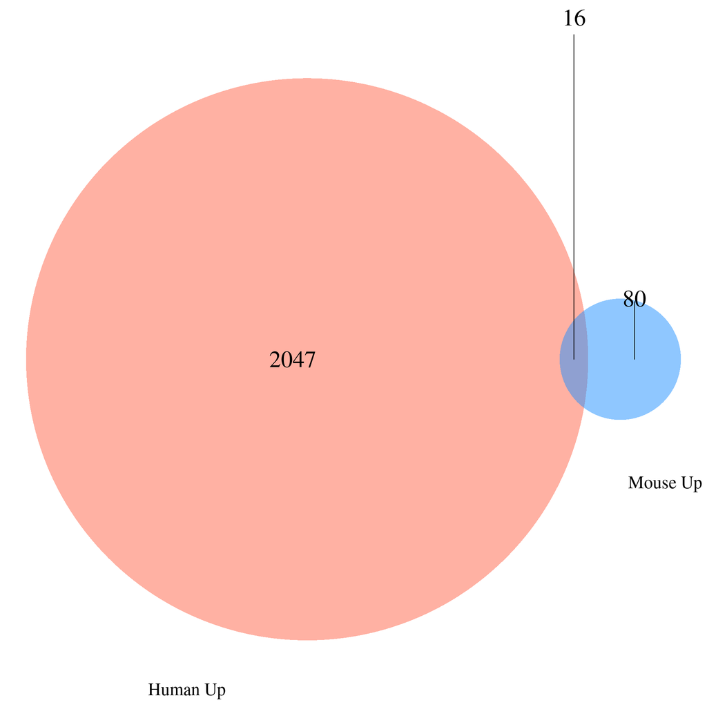

```r
# visualize the overlap of upregulated near-peak genes
library(VennDiagram)
library(grid)
grid.newpage() # create a new plotting page
venn.plot.up <- invisible(draw.pairwise.venn(
  area1 = nrow(up_mouse_orth),
  area2 = length(up_human_ids),
  cross.area = nrow(shared_up_orthologs),
  category = c("Mouse Up", "Human Up"),
  fill = c("dodgerblue", "tomato"),
  alpha = 0.5,
  lty = "blank",
  cex = 2,
  cat.cex = 1.5,
  cat.pos = c(-20, 20),
  cat.dist = 0.05
))
```

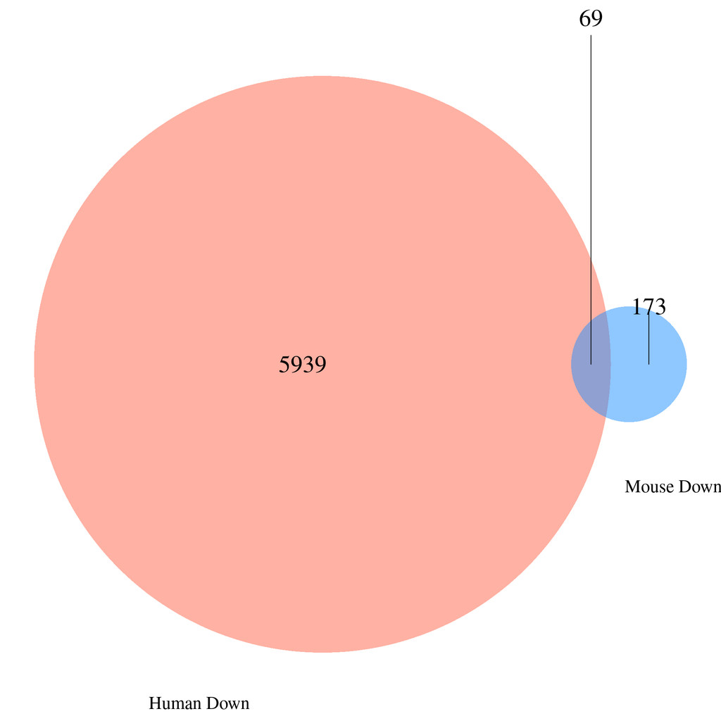

```r
# visualize the overlap of downregulated near-peak genes
grid.newpage()
venn.plot.down <- invisible(draw.pairwise.venn(
  area1 = nrow(down_mouse_orth),
  area2 = length(down_human_ids),
  cross.area = nrow(shared_down_orthologs),
  category = c("Mouse Down", "Human Down"),
  fill = c("dodgerblue", "tomato"),
  alpha = 0.5,
  lty = "blank",
  cex = 2,
  cat.cex = 1.5,
  cat.pos = c(-20, 20),
  cat.dist = 0.05
))
```

## ATAC-seq Analysis - Chromatin Accessibility

#### Now, we want to understand what mechanisms are contributing to these changes at the transcriptional level. How are these genes being regulated?

- While there are many levels of gene regulation, changing the chromatin lanscape to make certain genes more accessible to transcriptional machinery is a very likely possibility.
- So we will also analyze ATAC-seq (Assay for Transposase-Accessible Chromatin) to determine if the changes we’re seeing are reflected in the chromatin.

#### ATAC Analysis Approach:

1. Load in peak files to list of GRanges –> using custom function “import_peaks”.
2. Find peaks common to all samples.
3. Find peaks that are unique to dox and control conditions, respectively.
4. Determine if any of these peaks align with annotated mouse genes
5. Compare the overlapping peaks that are annotated - genes
6. Perform statistical analysis of differential accessibility using DESeq2
7. Look for any interesting relationships between peak accessibility and gene expression - i.e. are the genes upregulated in response to dox accessible in all conditions?

##### Where are my MACS2 outputs?

Loading in ATAC peak files using our custom function: import_peaks (output = list of GRanges).

```r
source("/scratch/Shares/rinnclass/MASTER_CLASS/STUDENTS/eroc4824/MASTER_CLASS/util/00_our_first_ATAC_function.R")

# establish peak path to the directory with MACS2 output files from NF_CORE ATAC-seq pipeline
peak_path <- "/scratch/Shares/rinnclass/MASTER_CLASS/lessons/08_ATACseq_pipeline/00_run_pipeline/00_pipeline_run/pipeline_run/bwa/merged_library/macs2/broad_peak"

# creating a file list also needed for import_peaks function to get sample name associated with file
fl <- list.files(peak_path, full.names = TRUE, pattern = ".broadPeak")

# running import_peaks
my_peaks <- import_peaks(consensus_file_path = peak_path)

# Calculate the number of peaks
num_peaks <- sapply(my_peaks, length) %>% as.data.frame()

cat("Number of peaks for each sample\n")
```

```
## Number of peaks for each sample
```

```r
knitr::kable(
  num_peaks,
  col.names = "Number of Peaks",
  caption = "Number of Peaks for Each Sample"
)
```

Number of Peaks for Each Sample

|  | Number of Peaks |
| --- | --- |
| KO_control_0 | 82031 |
| KO_control_120 | 95582 |
| KO_control_150 | 85303 |
| KO_control_30 | 71018 |
| KO_control_60 | 73631 |
| KO_control_90 | 94432 |
| WT_control_0 | 67410 |
| WT_control_120 | 79053 |
| WT_control_150 | 77512 |
| WT_control_30 | 68449 |
| WT_control_60 | 71773 |
| WT_control_90 | 78247 |

##### Find the peaks common to all mouse conditions / samples:

Identify the peaks that are called by MACS2 in all the time points. These sites are likely unimportant to the dox response that we see in terms of gene expression.

```r
# using find_common_peaks function:
common_peaks <-  find_common_peaks(my_peaks)

length(common_peaks)
```

```
## [1] 37152
```

##### Now find the MACS2-called peaks that are unique to the dox time points and the baseline 0min control:

Use the function “find_common_peaks” to find peaks specific to each condition.

Unique to non-dox samples (0 min time point):

```r
# common peaks in non-dox (0 time point)
non_dox_samples <- my_peaks[c("KO_control_0", "WT_control_0")]
non_dox_common_peaks <- find_common_peaks(non_dox_samples)
print(c("Number of peaks common to non-dox:", length(non_dox_common_peaks)))
```

```
## [1] "Number of peaks common to non-dox:" "53747"
```

Unique to dox samples:

```r
# common peaks in dox time points
dox_samples <- names(my_peaks)[!grepl("_0$", names(my_peaks))]
dox_peaks <- my_peaks[dox_samples]
dox_common_peaks <- find_common_peaks(dox_peaks)
print(c("Number of peaks common to dox:",length(dox_common_peaks)))
```

```
## [1] "Number of peaks common to dox:" "38984"
```

Overlap of dox and non-dox (to get unique peaks for each condition)

```r
# overlap between dox and non-dox common peaks:
dox_compare_list <- list(non_dox = non_dox_common_peaks, dox = dox_common_peaks)
dox_non_dox_ov <- find_common_peaks(dox_compare_list)
print(c("This is how many peaks are common in both non- and dox treatments:", length(dox_non_dox_ov)))
```

```
## [1] "This is how many peaks are common in both non- and dox treatments:"
## [2] "37435"
```

```r
# extract peaks unique to each condition (dox v non-dox):
# Peaks unique to non_dox:
unique_to_non_dox <-find_my_peaks(dox_non_dox_ov, non_dox_common_peaks)
# Peaks unique to dox:
unique_to_dox <- find_my_peaks(dox_non_dox_ov, dox_common_peaks)
```

Number of peaks unique to non-dox condition: 16312

Number of peaks unique to dox condition: 1793

#### Create mouse gene, lncRNA, mRNA annotation GRange objects:

Now, create GRange objects of genome annotations from Gencode mv25. I will create gene annotation GRanges and their corresponding promoter regions. I can then overlap these objects with ATAC peaks.

```r
# Load gencode genome annotation as GRanges
# gencode_gr_mouse <- rtracklayer::import("/scratch/Shares/rinnclass/MASTER_CLASS/GENOMES/M25/gencode.vM25.annotation.gtf")

# Filter to genes only
# gencode_genes_mouse <- gencode_gr_mouse[gencode_gr_mouse$type == "gene"]
# Filter for promoters
# gene_promoters <- promoters(gencode_genes_mouse, upstream = 2000, downstream = 2000)

# save GTF filtered for genes into my directory so I don't need to import whole GTF each time
# saveRDS(gencode_genes_mouse, file = "/scratch/Shares/rinnclass/MASTER_CLASS/STUDENTS/eroc4824/MASTER_CLASS/lessons/08_ATACseq_pipeline/eroc4824_FINAL_PROJECT/Genomes/gencode.vM25.genes_only.rds")

# save GTF filtered for promoters regions to the same final directory:
# saveRDS(gene_promoters, file = "/scratch/Shares/rinnclass/MASTER_CLASS/STUDENTS/eroc4824/MASTER_CLASS/lessons/08_ATACseq_pipeline/eroc4824_FINAL_PROJECT/Genomes/gencode.vM25.promoters_only.rds")

gencode_genes_mouse <- readRDS("/scratch/Shares/rinnclass/MASTER_CLASS/STUDENTS/eroc4824/MASTER_CLASS/lessons/08_ATACseq_pipeline/eroc4824_FINAL_PROJECT/Genomes/gencode.vM25.genes_only.rds")

gene_promoters <- readRDS("/scratch/Shares/rinnclass/MASTER_CLASS/STUDENTS/eroc4824/MASTER_CLASS/lessons/08_ATACseq_pipeline/eroc4824_FINAL_PROJECT/Genomes/gencode.vM25.promoters_only.rds")
```

#### Now we can look at the overlap between the called mouse peaks unique to each condition and the annotation objects we’ve created here:

```r
# gr_list of promoters and peaks unique to non_dox condition
gr_list_gene_promoter_non_dox_ov <- list( gene_promoters = gene_promoters, non_dox_peaks = unique_to_non_dox)
non_dox_gene_promoter_ov <- find_common_peaks(gr_list_gene_promoter_non_dox_ov)

print("This is how many non-dox_unique peaks overlapped gene promoters")
```

```
## [1] "This is how many non-dox_unique peaks overlapped gene promoters"
```

```r
length(non_dox_gene_promoter_ov)
```

```
## [1] 2178
```

```r
# peaks unique to dox condition overlapped with gene promoters
gr_list_gene_promoter_dox_ov <- list( gene_promoters = gene_promoters, dox_peaks = unique_to_dox)
dox_gene_promoter_ov <- find_common_peaks(gr_list_gene_promoter_dox_ov)

print(c("This is how many dox_unique peaks overlapped gene promoters", length(dox_gene_promoter_ov)))
```

```
## [1] "This is how many dox_unique peaks overlapped gene promoters"
## [2] "239"
```

```r
# filter significant genes from RNAseq "filtered_res_df_mouse" to non-dox unique promoter overlaps
sig_rnaseq_atac_non_dox <- non_dox_gene_promoter_ov[non_dox_gene_promoter_ov$gene_id %in% filtered_res_df_mouse$gene_id]

# filter significant genes from RNAseq "filtered_res_df_mouse" to dox unique promoter overlaps
sig_rnaseq_atac_dox <- dox_gene_promoter_ov[dox_gene_promoter_ov$gene_id %in% filtered_res_df_mouse$gene_id]

print(c("this is how many genes overlap between RNAseq and ATACseq non-dox peaks", length(sig_rnaseq_atac_dox)))
```

```
## [1] "this is how many genes overlap between RNAseq and ATACseq non-dox peaks"
## [2] "4"
```

Number of genes that overlap between RNA-seq and ATAC-seq non-dox peaks: 48

Here are the gene names that overlap for non-dox peaks: 9830004L10Rik, Pla2g4f, Mal, Gm14292, BC028528, Itga10, Gm12854, Ccdc24, Spon2, Plk-ps1, Hs3st1, Igfbp7, Foxn4, Gm10443, Rpl36-ps12, Rpl18-ps2, Zscan5b, Rps12-ps4, Mybpc2, Car11, Igf2, Il27ra, Ccdc113, Gm10073, Cnn1, Chrnb4, Gm47594, Myo1g, Gm12091, Slc47a1, Tm4sf5, Gm12345, Gm11611, Gm11703, Hsp25-ps1, Gm6169, Zfp503, Slc7a7, Gm49510, Mei1, Lrrc15, Gm2541, Oaz1-ps, Gm16580, Trp53cor1, Gm4708, Cyp1b1, Gm7153

Number of genes that overlap between RNA-seq and ATAC-seq dox peaks: 4

Here are the gene names that overlap for dox peaks: Neurod1, Cnksr1, Prcd, Dct

##### Visualize the overlap with ggplot Venn Diagram:

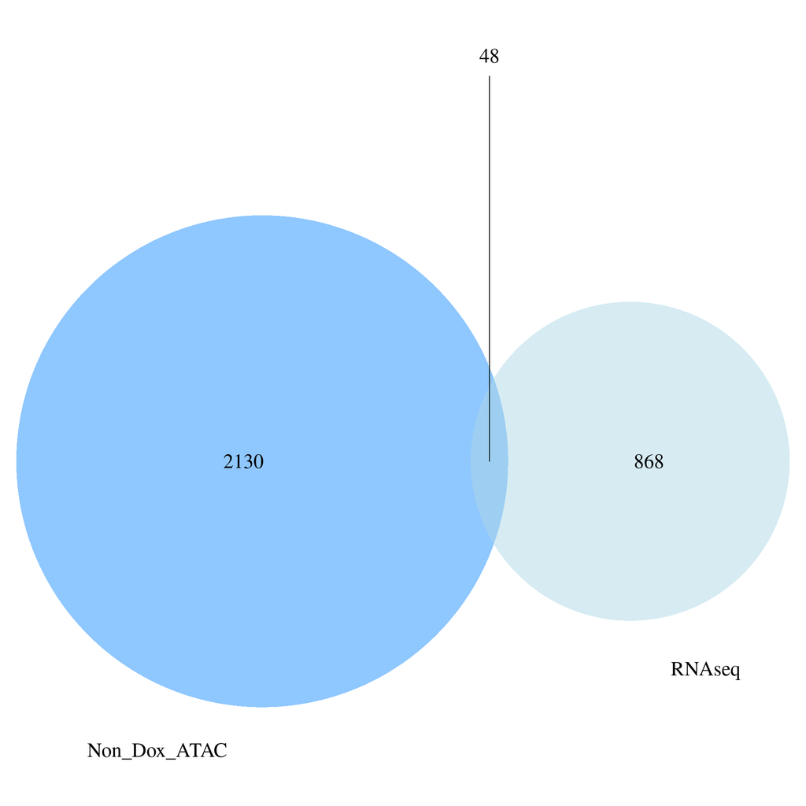

```r
# Install and load the VennDiagram package
# install.packages("VennDiagram", repos = "https://cloud.r-project.org")
library(VennDiagram)

# ---- Venn: Non-Dox RNA vs ATAC ----
rna_genes <- filtered_res_df_mouse$gene_id
non_dox_genes <- non_dox_gene_promoter_ov$gene_id
overlap_nd <- length(intersect(rna_genes, non_dox_genes))

grid.newpage()  # Create a new plotting page
venn.plot.nd <- invisible(draw.pairwise.venn(
  area1 = length(rna_genes),
  area2 = length(non_dox_genes),
  cross.area = overlap_nd,
  category = c("RNAseq", "Non_Dox_ATAC"),
  fill = c("lightblue", "dodgerblue"),
  alpha = 0.5,
  lty = "blank",
  cex = 1.5,
  cat.cex = 1.5,
  cat.pos = c(-20, 20),
  cat.dist = 0.05
))
```

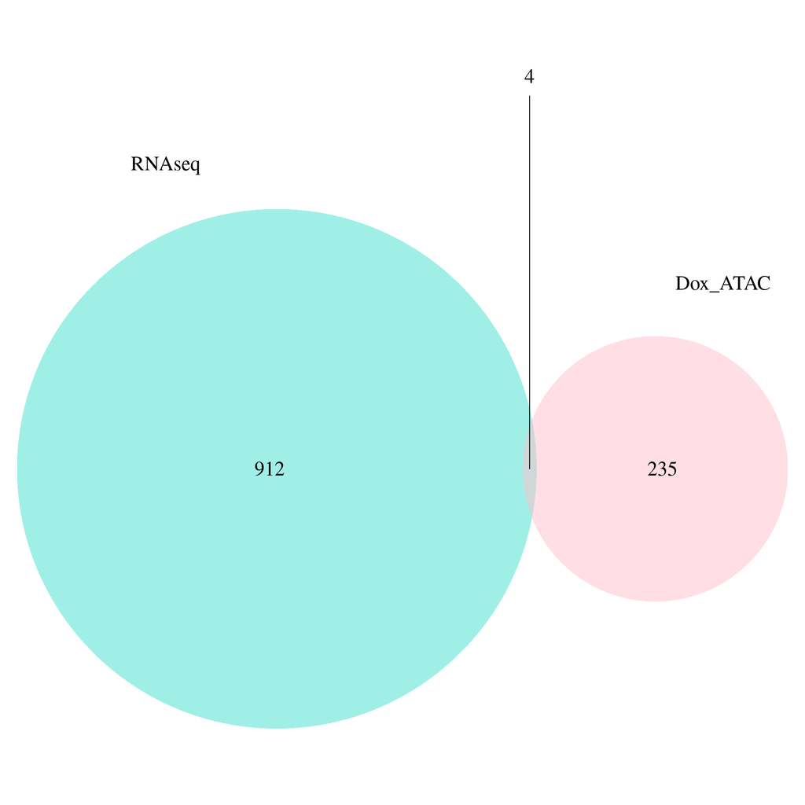

```r
# ---- Venn: Dox RNA vs ATAC ----
dox_genes <- dox_gene_promoter_ov$gene_id
overlap_dox <- length(intersect(rna_genes, dox_genes))

grid.newpage()
venn.plot.dox <- invisible(draw.pairwise.venn(
  area1 = length(rna_genes),
  area2 = length(dox_genes),
  cross.area = overlap_dox,
  category = c("RNAseq", "Dox_ATAC"),
  fill = c("turquoise", "pink"),
  alpha = 0.5,
  lty = "blank",
  cex = 1.5,
  cat.cex = 1.5,
  cat.pos = c(-20, 20),
  cat.dist = 0.05
))
```

##### Result - There is essentially no overlap between the differentially expressed genes and the called peaks in either condition in mouse.

#### DESeq Analysis to look for significantly differentially accessible peaks for mouse:

Now I am comparing peak read counts across samples for dox and non-dox conditions. To do this, I’ll use the consensus peaks output (any peak called in any condition) and feature counts of each consensus peak to be used as input into DESeq2 for differential peak counts (a very similar approach to the RNA-seq DESeq analysis).

```r
# consensus peaks
broad_consensus_peaks <- read.table("/scratch/Shares/rinnclass/MASTER_CLASS/lessons/08_ATACseq_pipeline/00_run_pipeline/00_pipeline_run/pipeline_run/bwa/merged_library/macs2/broad_peak/consensus/consensus_peaks.mLb.clN.annotatePeaks.txt", sep = "\t", header = TRUE)

# consensus peak counts
broad_consensus_counts <- read.table("/scratch/Shares/rinnclass/MASTER_CLASS/lessons/08_ATACseq_pipeline/00_run_pipeline/00_pipeline_run/pipeline_run/bwa/merged_library/macs2/broad_peak/consensus/consensus_peaks.mLb.clN.featureCounts.txt", sep = "\t", header = TRUE)

# creating sample sheet "atac_samples" from file names (col names of consensus):
rownames(broad_consensus_counts) <- broad_consensus_counts$Geneid

broad_consensus_counts <- broad_consensus_counts %>%
  dplyr::select(-c(Geneid, Chr, Start, End, Strand, Length))
colnames(broad_consensus_counts) <- gsub("_REP1",
                                         "_R1",
                                         gsub(
                                           "\\.mLb\\.clN\\.sorted\\.bam",
                                           "",
                                           colnames(broad_consensus_counts)
                                         ))
count_columns <- colnames(broad_consensus_counts)

atac_samples <- data.frame(
  sample = count_columns,
  condition = ifelse(
    grepl("_0_", count_columns),
    "non-dox",
    ifelse(grepl("non-dox", count_columns), "non-dox", "dox")
  ),
  timepoint_minutes = as.numeric(sub(".*_(\\d+)_R1.*", "\\1", count_columns))
)

# Factor condition for DESEQ2
atac_samples <- atac_samples %>%
  mutate(condition = factor(condition, levels = c("non-dox", "dox")))

# matrix for Deseq2
atac_dds_condition <- DESeqDataSetFromMatrix(countData = broad_consensus_counts,
                                   colData = atac_samples,
                                   design = ~ condition)
# Run DESeq2 condition model
atac_dds_condition <- DESeq(atac_dds_condition)
```

#### Extract and analyze the mouse DESeq2 results:

Create a dataframe with pvalues and lfc etc

```r
# Extract DESeq2 results
atac_lfc_condition <- results(atac_dds_condition) %>%
  as.data.frame() %>%
  rownames_to_column("interval_id")

# Merge with the broad_consensus_peaks
colnames(broad_consensus_peaks)[1] <- "interval_id"

atac_lfc_condition <- merge(atac_lfc_condition,
                  broad_consensus_peaks %>%
                    dplyr::select(interval_id, Gene.Name, Nearest.PromoterID,
                                  Distance.to.TSS, Chr, Start, End),
                  by = "interval_id")
```

#### Visualize the distribution of adjusted p-values:

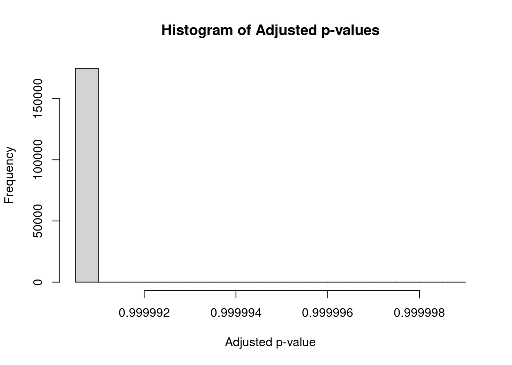

```r
hist(atac_lfc_condition$padj, main = "Histogram of Adjusted p-values", xlab = "Adjusted p-value")
```

It looks like all our adjusted p-values are close to 1, and none seem to be significant.

#### Now, let’s filter this list based on adjusted p-value to confirm this:

```r
sig_atac_peaks <- atac_lfc_condition %>% dplyr::filter(!is.na(padj) & padj < 0.05)
length(sig_atac_peaks$Gene.Name)
```

```
## [1] 0
```

### Result - there are no significant differences in chromatin accessibility with dox treatment in mouse embryonic stem cells.

This finding is interesting on its own and informs us about the level of gene regulation involved in the response to dox, pointing towards other kinds of co-transcriptional or post-transcriptional regulation. But there is not much else we can do to look at the dox response through the lens of chromatin regulation.

### What other questions can we ask to learn more from these ATAC data sets?

#### New analysis objective: What is the relationship betweek peak accessibility and gene expression in embryonic stem cells, and is this relationship conserved across species?

I am going to look for peaks that are always near a gene and ask if those genes are also more expressed (in all conditions). i.e. does having more accessible regulatory elements near a gene make it more likely to be highly expressed?

In other words, we are asking: if these peaks are always present next to a gene (and may promote higher gene expression), is this kind of relationship between genomic regions conserved in different mammalian species (mouse v human)?

For the ATAC-seq analysis, I will use the MACS2 output files from the NF_CORE Pipeline –> i.e. -broad.peak -consensus.broad.peak -consensus.feature.counts

### (1) Identify peaks near genes, common to all samples (mouse and human)

This tells us there’s an ATAC peak near these genes in all samples

#### Define mouse peaks that are within 5kb upstream or downstream of the TSS (TSS regions):

```r
tss_regions_mouse <- promoters(gencode_genes_mouse, upstream = 5000, downstream = 5000)
```

#### Find common overlap across all mouse samples using “find_common_peaks” function:

```r
# Find common peaks across all mouse samples (my_peaks that we defined earlier)
common_peaks_mouse <- find_common_peaks(my_peaks)

# create a list of two GRanges objects:
gr_list_common_peaks_mouse <- list(
  tss_regions = tss_regions_mouse,
  common_peaks = common_peaks_mouse
)

# then pass this list through the find_common_peaks function we've already defined:
peaks_near_genes_mouse <- find_common_peaks(gr_list_common_peaks_mouse)
length(peaks_near_genes_mouse)
```

```
## [1] 22111
```

#### Result - there are 22,111 peaks-near-genes that are common across all the mouse samples

### Now do the same thing with the human ATAC data:

#### Load the human ATAC data:

```r
source("/scratch/Shares/rinnclass/MASTER_CLASS/STUDENTS/eroc4824/MASTER_CLASS/util/00_our_first_ATAC_function.R")
human_peak_path <- "/scratch/Shares/rinnclass/MASTER_CLASS/DATA/human_atacseq"

# include only 1 replicate per time point to be consistent between human and mouse:
rep1_files <- list.files(human_peak_path, full.names = TRUE, pattern = "REP1.*broadPeak$")

# load peak files into a list of GRanges objects
human_peaks <- import_peaks_human(consensus_file_path = human_peak_path, pattern = "REP1.*broadPeak$")

# Calculate number of peaks for each sample
num_peaks_human <- sapply(human_peaks, length) %>%
  as.data.frame() %>%
  tibble::rownames_to_column(var = "Sample")  # optional: add sample names as a column

cat("Number of peaks for each human sample\n")
```

```
## Number of peaks for each human sample
```

```r
knitr::kable(num_peaks_human, col.names = c("Sample", "Number of Peaks"), caption = "Number of Peaks for Each Human Sample")
```

Number of Peaks for Each Human Sample

| Sample | Number of Peaks |
| --- | --- |
| novageneGFP_0.5h_REP1 | 148391 |
| novageneGFP_0h_REP1 | 148083 |
| novageneGFP_1.5h_REP1 | 115685 |
| novageneGFP_1h_REP1 | 89923 |
| novageneGFP_2.5h_REP1 | 144102 |
| novageneGFP_2h_REP1 | 136505 |

#### Find the peaks common to all human samples:

Identify the peaks that are called by MACS2 in all the time points.

```r
# use the find_common_peaks function:
common_peaks_human <-  find_common_peaks(human_peaks)

length(common_peaks_human)
```

```
## [1] 63989
```

#### Load the human genome data and define promoter/TSS regions:

```r
# Load human gencode genome annotation
# This import takes a LOT of time, so we can actually just load the gene feature information, since for this analysis, we don't need info on transcript, exon, UTR, etc
# gencode_gr_human <- rtracklayer::import("/scratch/Shares/rinnclass/MASTER_CLASS/DATA/genomes/Homo_sapiens/Gencode/v38/gencode.v38.annotation.gtf", feature.type = "gene")

# Extract gene entries only (redundant since we only imported genes, but good to be sure):
# gencode_genes_human <- gencode_gr_human[gencode_gr_human$type == "gene"]

# saveRDS(gencode_genes_human, file = "/scratch/Shares/rinnclass/MASTER_CLASS/STUDENTS/eroc4824/MASTER_CLASS/lessons/08_ATACseq_pipeline/eroc4824_FINAL_PROJECT/Genomes/gencode.v38.human_genes_only.rds")

gencode_genes_human <- readRDS("/scratch/Shares/rinnclass/MASTER_CLASS/STUDENTS/eroc4824/MASTER_CLASS/lessons/08_ATACseq_pipeline/eroc4824_FINAL_PROJECT/Genomes/gencode.v38.human_genes_only.rds")

# Define ±5kb regions around TSS
tss_regions_human <- promoters(gencode_genes_human, upstream = 5000, downstream = 5000)
```

#### Find common overlap across all human samples using “find_common_peaks” function:

```r
# create a list of two GRanges objects:
gr_list_common_peaks_human <- list(
  tss_regions = tss_regions_human,
  common_peaks = common_peaks_human
)

# then pass this list through the find_common_peaks function we've already defined:
peaks_near_genes_human <- find_common_peaks(gr_list_common_peaks_human)
length(peaks_near_genes_human)
```

```
## [1] 28901
```

##### Result - there are 28,901 peaks-near-genes that are common across all the human samples

#### (2) Compare expression of genes with and without nearby peaks

I will use the 0 hour RNA-seq sample for a cleaner comparison, since we aren’t asking anything related to dox exposure in this case.

Workflow: - Define gene groups - Extract expression - Get average expression per gene at time 0 - Compare groups - visualize with violin plots, test significance with a wilcox test to compare expression distributions

#### Start with mouse:

#### Define mouse gene lists that you want to compare:

```r
# Genes with nearby peaks
genes_with_peaks_mouse <- unique(peaks_near_genes_mouse$gene_id)

# All genes from annotation
all_genes_mouse <- unique(gencode_genes_mouse$gene_id)

# Genes without nearby peaks
genes_without_peaks_mouse <- setdiff(all_genes_mouse, genes_with_peaks_mouse)
```

#### Next, load the TPM (normalized counts) for mouse and isolate 0h samples:

TPM normalizes for gene length and for sequencing depth, so this is better for comparing gene expression. I will use 0h baseline control samples since dox exposure is not relevant to our current question.

```r
# Load TPM matrix (from Salmon output)
TPM_mouse <- read.table("/scratch/Shares/rinnclass/MASTER_CLASS/STUDENTS/eroc4824/MASTER_CLASS/lessons/04_RNAseq_Dox/01_Mouse_dox_wt/dox_long/dox_long_out/star_salmon/salmon.merged.gene_tpm.tsv",
                        header = TRUE, row.names = 1)

# Remove gene_name column
TPM_mouse <- TPM_mouse[, -1]

# Filter for 0h samples only
tpm_mouse_0h <- TPM_mouse[, grepl("WT_0_", colnames(TPM_mouse))]

# Find average expression for each gene (across 0h replicates)
avg_0_expr_mouse <- rowMeans(tpm_mouse_0h)
```

#### Build a data frame with mouse gene ID and expression:

```r
# Create a data frame of gene_id and expression
mouse_tpm_peak_annotated <- data.frame(
  gene_id = names(avg_0_expr_mouse),
  avg_expr = avg_0_expr_mouse
)

# Label genes as 'With Peak' or 'Without Peak'
mouse_tpm_peak_annotated$group <- ifelse(mouse_tpm_peak_annotated$gene_id %in% genes_with_peaks_mouse,
                              "With Peak",
                              ifelse(mouse_tpm_peak_annotated$gene_id %in% genes_without_peaks_mouse,
                                     "Without Peak", NA))

# Drop NAs (genes not found in either group)
mouse_tpm_peak_annotated <- mouse_tpm_peak_annotated[!is.na(mouse_tpm_peak_annotated$group), ]
```

#### Visualize the expression differences

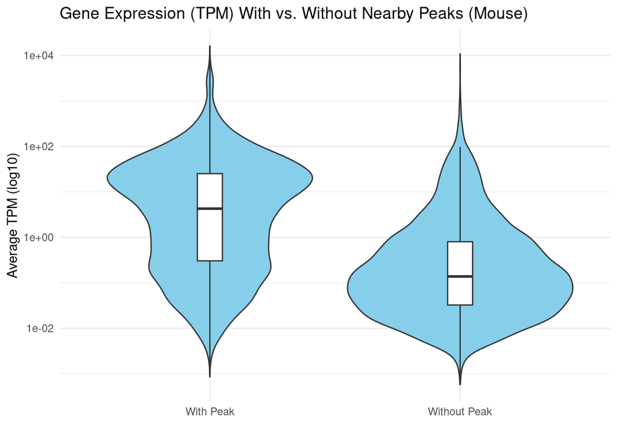

```r
library(ggplot2)

ggplot(mouse_tpm_peak_annotated, aes(x = group, y = avg_expr)) +
  geom_violin(fill = "skyblue") +
  geom_boxplot(width = 0.1, outlier.shape = NA) +
  scale_y_log10() +
  labs(title = "Gene Expression (TPM) With vs. Without Nearby Peaks (Mouse)",
       x = "", y = "Average TPM (log10)") +
  theme_minimal()
```

#### Test statistical difference

```r
with_peak_expr_mouse <- mouse_tpm_peak_annotated %>% filter(group == "With Peak") %>% pull(avg_expr)
without_peak_expr_mouse <- mouse_tpm_peak_annotated %>% filter(group == "Without Peak") %>% pull(avg_expr)

wilcox.test(with_peak_expr_mouse, without_peak_expr_mouse)
```

```
##
##  Wilcoxon rank sum test with continuity correction
##
## data:  with_peak_expr_mouse and without_peak_expr_mouse
## W = 602207570, p-value < 2.2e-16
## alternative hypothesis: true location shift is not equal to 0
```

#### Result for the wilcox rank sum test - W = 602207570, p-value < 2.2e-16

This means that the mouse genes with a nearby peak are significantly more expressed than genes that are not near a peak.

#### Now do the same for human -

#### Define human gene lists with or without a nearby peak:

```r
# Genes with a peak nearby (from TSS region overlap)
genes_with_peaks_human <- unique(peaks_near_genes_human$gene_id)

# All annotated genes
all_genes_human <- unique(gencode_genes_human$gene_id)

# Genes without nearby peaks
genes_without_peaks_human <- setdiff(all_genes_human, genes_with_peaks_human)
```

#### Load human TPM and isolate 0h samples:

```r
# Load TPM matrix (from human Salmon output)
TPM_human <- read.table("/scratch/Shares/rinnclass/MASTER_CLASS/DATA/human_rnaseq/salmon.merged.gene_tpm.tsv",
                        header = TRUE, row.names = 1)

# Drop gene_name column
TPM_human <- TPM_human[, -1]

# Keep only 0h samples
tpm_human_0h <- TPM_human[, grepl("gfp_0_", colnames(TPM_human))]

# calculate avg TPM value for 0h
avg_0_expr_human <- rowMeans(tpm_human_0h)
```

#### Build a data frame with human gene ID and expression:

```r
human_tpm_peak_annotated <- data.frame(
  gene_id = names(avg_0_expr_human),
  avg_expr = avg_0_expr_human)

human_tpm_peak_annotated$group <- ifelse(human_tpm_peak_annotated$gene_id %in% genes_with_peaks_human, "With Peak", ifelse(human_tpm_peak_annotated$gene_id %in% genes_without_peaks_human, "Without Peak", NA))

# Remove NAs (genes not in either group)
human_tpm_peak_annotated <- human_tpm_peak_annotated[!is.na(human_tpm_peak_annotated$group), ]
```

#### visualize the human expression differences

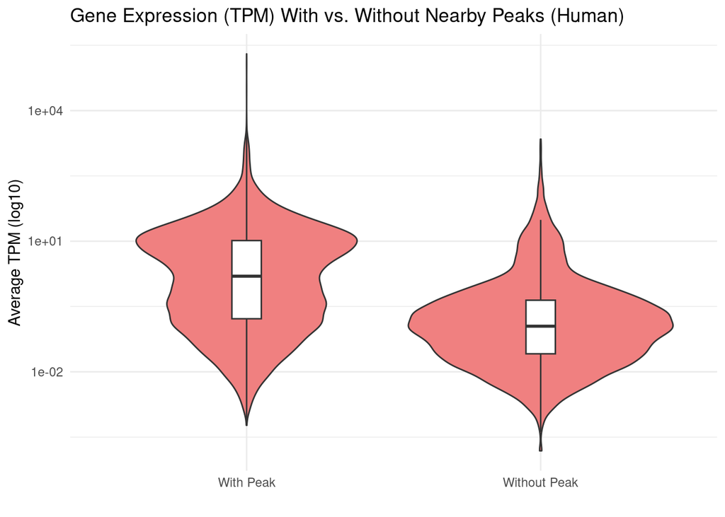

```r
ggplot(human_tpm_peak_annotated, aes(x = group, y = avg_expr)) +
  geom_violin(fill = "lightcoral") +
  geom_boxplot(width = 0.1, outlier.shape = NA) +
  scale_y_log10() +
  labs(title = "Gene Expression (TPM) With vs. Without Nearby Peaks (Human)",
       x = "", y = "Average TPM (log10)") +
  theme_minimal()
```

#### Test statistical difference

```r
table(human_tpm_peak_annotated$group)
```

```
##
##    With Peak Without Peak
##        28901        31748
```

```r
with_peak_expr_human <- human_tpm_peak_annotated %>% filter(group == "With Peak") %>% pull(avg_expr)
without_peak_expr_human <- human_tpm_peak_annotated %>% filter(group == "Without Peak") %>% pull(avg_expr)

wilcox.test(with_peak_expr_human, without_peak_expr_human)
```

```
##
##  Wilcoxon rank sum test with continuity correction
##
## data:  with_peak_expr_human and without_peak_expr_human
## W = 705406301, p-value < 2.2e-16
## alternative hypothesis: true location shift is not equal to 0
```

#### Result from the wilxox rank sum test - W = 705406301, p-value < 2.2e-16

This means that the human genes with a nearby peak are significantly more expressed than genes that are not near a peak. So this holds true for human genes, and mouse genes. Next we’ll ask: Are genes with a nearby peak that also show higher expression conserved between mouse and human? Let’s look at the overlap of these gene lists.

#### (3) Identify genes that are both 1) expressed more highly near ATAC peaks and 2) Conserved between mouse and human

#### Load orthologs:

```r
orthologs_filtered <- read.csv("/scratch/Shares/rinnclass/MASTER_CLASS/STUDENTS/eroc4824/MASTER_CLASS/lessons/08_ATACseq_pipeline/eroc4824_FINAL_PROJECT/results/mouse_human_orthologs.csv")

# Remove version numbers from orthologs
orthologs_filtered <- orthologs_filtered %>%
  mutate(mouse_gene_id = sub("\\..*", "", mouse_gene_id),
         human_gene_id = sub("\\..*", "", human_gene_id))

# Remove version numbers from mouse
mouse_tpm_peak_annotated <- mouse_tpm_peak_annotated %>%
  mutate(gene_id = sub("\\..*", "", gene_id))
rownames(mouse_tpm_peak_annotated) <- mouse_tpm_peak_annotated$gene_id

# Remove version numbers from human
human_tpm_peak_annotated <- human_tpm_peak_annotated %>%
  mutate(gene_id = sub("\\..*", "", gene_id)) %>%
  distinct(gene_id, .keep_all = TRUE)
rownames(human_tpm_peak_annotated) <- human_tpm_peak_annotated$gene_id

# Only keep orthologs where the gene is present in both mouse and human
orthologs_filtered_expr <- orthologs_filtered %>%
  filter(mouse_gene_id %in% mouse_tpm_peak_annotated$gene_id &
         human_gene_id %in% human_tpm_peak_annotated$gene_id)

# Merge mouse expression (TPM) + orthologs
mouse_merged <- merge(orthologs_filtered_expr, mouse_tpm_peak_annotated,
                      by.x = "mouse_gene_id", by.y = "gene_id")

# Merge human expression to create a df with merged mouse-human orthologs and peak-proximity & TPM info:
combined_df <- merge(mouse_merged, human_tpm_peak_annotated,
                     by.x = "human_gene_id", by.y = "gene_id",
                     suffixes = c("_mouse", "_human"))
```

#### Subset the “high expression with nearby peaks” conserved genes:

Now we are creating a data frame with genes that: (1) Have a nearby accessible peak (2) Have higher than average expression (3) Is an ortholog present in both human and mouse

```r
# Create df of conserved highly-expressed-near-peaks genes:
# Also ignores "NA"s
conserved_peak_expr_genes <- combined_df %>%
  filter(group_mouse == "With Peak", group_human == "With Peak") %>%
  filter(avg_expr_mouse > median(mouse_tpm_peak_annotated$avg_expr, na.rm = TRUE),
         avg_expr_human > median(human_tpm_peak_annotated$avg_expr, na.rm = TRUE))

# How many conserved genes?
cat("Number of conserved genes with nearby peaks and high expression:", nrow(conserved_peak_expr_genes), "\n")
```

```
## Number of conserved genes with nearby peaks and high expression: 11084
```

```r
# Preview the conserved genes
kable(head(conserved_peak_expr_genes), caption = "Conserved genes with nearby peaks and high expression")
```

Conserved genes with nearby peaks and high expression

| human_gene_id | mouse_gene_id | mouse_gene_name | human_gene_name | orthology_type | avg_expr_mouse | group_mouse | avg_expr_human | group_human |
| --- | --- | --- | --- | --- | --- | --- | --- | --- |
| ENSG00000000419 | ENSMUSG00000078919 | Dpm1 | DPM1 | ortholog_one2one | 40.908321 | With Peak | 35.888724 | With Peak |
| ENSG00000000457 | ENSMUSG00000026584 | Scyl3 | SCYL3 | ortholog_one2one | 11.205105 | With Peak | 1.955297 | With Peak |
| ENSG00000000460 | ENSMUSG00000041406 | Firrm | FIRRM | ortholog_one2one | 48.950546 | With Peak | 12.102525 | With Peak |
| ENSG00000001036 | ENSMUSG00000019810 | Fuca2 | FUCA2 | ortholog_one2one | 13.439663 | With Peak | 20.808837 | With Peak |
| ENSG00000001460 | ENSMUSG00000028801 | Stpg1 | STPG1 | ortholog_one2one | 0.280660 | With Peak | 3.331906 | With Peak |
| ENSG00000001461 | ENSMUSG00000028803 | Nipal3 | NIPAL3 | ortholog_one2one | 5.352918 | With Peak | 2.842032 | With Peak |

```r
# Save results in a table:
write.csv(conserved_peak_expr_genes, "/scratch/Shares/rinnclass/MASTER_CLASS/STUDENTS/eroc4824/MASTER_CLASS/lessons/08_ATACseq_pipeline/eroc4824_FINAL_PROJECT/results/conserved_peak_nearby_high_expr_genes.csv", row.names = FALSE)
```

#### Now visualize the mouse and human data together in a violin plot:

This will give a nice comparison to see if both species have a conserved pattern with higher expression of genes that are near peaks.

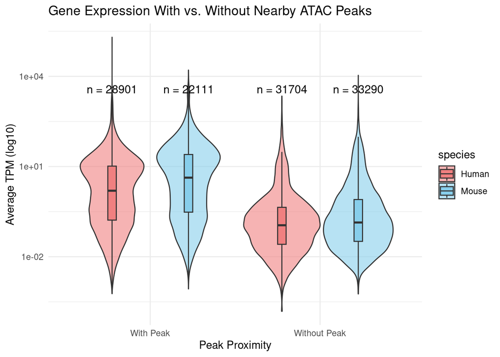

```r
# Add species label to each dataset
mouse_tpm_peak_annotated$species <- "Mouse"
human_tpm_peak_annotated$species <- "Human"

# combine the two data frames
all_tpm_peak_annotated <- bind_rows(mouse_tpm_peak_annotated, human_tpm_peak_annotated)

# create a summary table with counts (we'll use this to label number of genes)
group_counts <- all_tpm_peak_annotated %>%
  group_by(species, group) %>%
  summarise(n = n(), .groups = "drop")

# and plot:
ggplot(all_tpm_peak_annotated, aes(x = group, y = avg_expr, fill = species)) +
  geom_violin(position = position_dodge(width = 0.9), alpha = 0.6) +
  geom_boxplot(width = 0.1, position = position_dodge(width = 0.9), outlier.shape = NA) +
  scale_y_log10() +
  labs(title = "Gene Expression With vs. Without Nearby ATAC Peaks",
       x = "Peak Proximity", y = "Average TPM (log10)") +
  theme_minimal() +
  scale_fill_manual(values = c("Mouse" = "skyblue", "Human" = "lightcoral")) +
  geom_text(data = group_counts,
            aes(x = group, y = 2000, label = paste0("n = ", n), group = species),
            position = position_dodge(width = 0.9),
            size = 4, vjust = -0.5)
```

#### The trend is the same for each species, and this is statistically significant.

#### Result - there are 11,084 human and mouse orthologs that are expressed more highly when they have a nearby accessible peak (within 5kb of the gene’s TSS).

- This tells us that genes with nearby accessible chromatin regions tend to be more highly expressed, and this pattern is strongly conserved between mouse and human embryonic stem cells.
- This also supports a really important concept for gene regulation that promoter and enhancer accessibility is really important for transcriptional activation, and this relationship is evolutionarily conserved.

#### Future directions:

- Explore what these genes are - gene ontology, pathway enrichment analysis
- Explore the composition of these accessible peaks (i.e. promoters vs enhancers)
- Explore at what point during differentiation these peaks become inaccessible. Which of these will change and which will remain accessible (i.e. housekeeping genes)?